# External Controls in Oncology Clinical Trials

Are these things legitimate?

Causation & Clinical Trials

Author

Mark Zobeck

Published

January 11, 2025

Modified

January 17, 2025

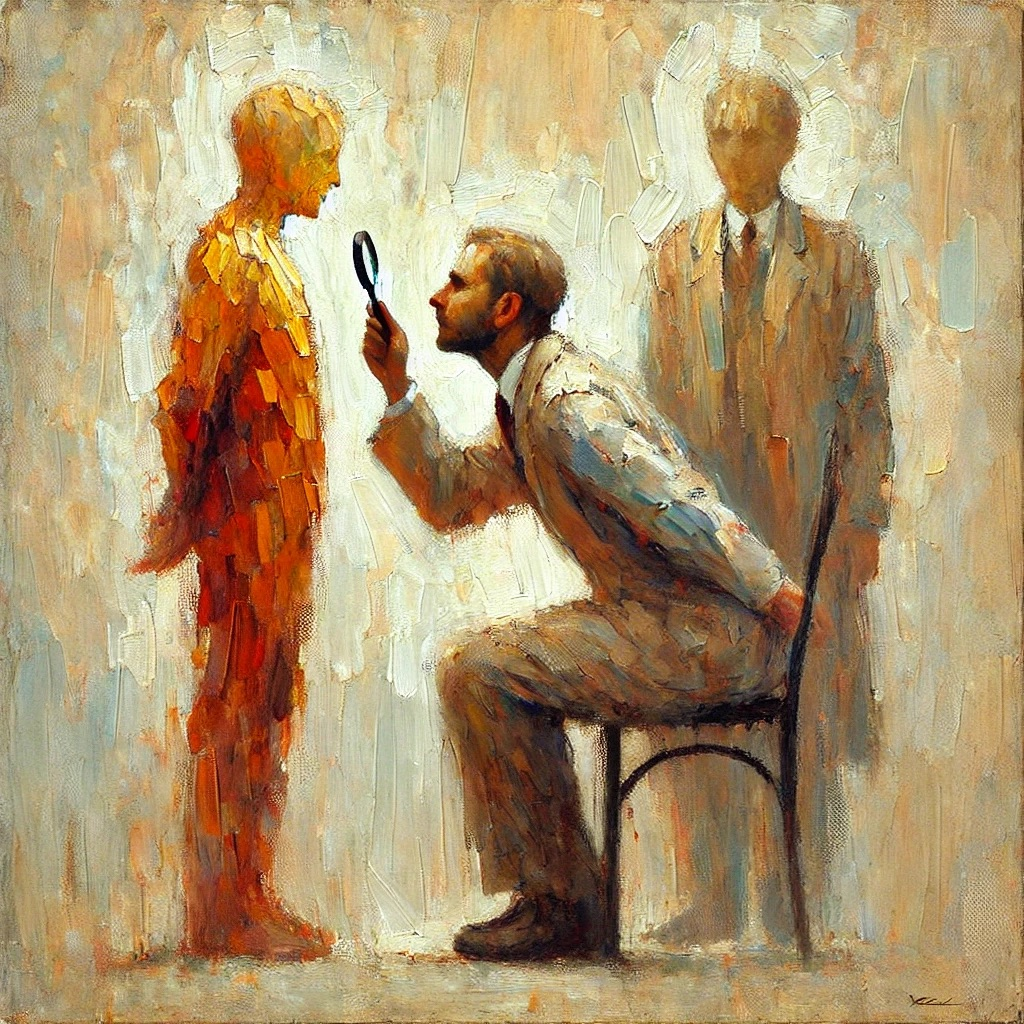

## Introduction

External controls are, for better or worse, common in pediatric oncology clinical trials. I don’t love them. They are dangerous. However, there are arguments in their favor. In this post, I’ll briefly discuss what historical controls are, when their use might be justified, and why they’re dangerous.

## What are external controls?

The purpose of clinical trials is to evaluate the effect of a treatment in some population of patients. In a classic randomized clinical trial, patients who meet the study criteria are randomized to either receive the standard of care for their disease or a new treatment. The outcome between the two groups is compared, and due to the miracle of randomization, the treatment effect can be identified as the difference in the outcomes between the groups.

External controls are a group of patients not enrolled in a clinical trial but used as a comparison group for patients on a trial. The difference between the outcomes for the controls and the treatment group is taken as the effect of treatment, much like the comparison with the standard of care arm in a clinical trial. For valid comparisons, the control group should look as similar as possible to those that could have been enrolled in the trial. The group may be taken from a previous clinical trial, a patient registry, or other real-world data source. The key limitation of this design is that external controls do not benefit from the wonders of randomization, which makes bias a much greater danger when estimating the effect of treatment.

## Why we might use external controls

External controls are generally used when trialists cannot or should not enroll a comparison group for ethical reasons or because the disease is so rare. Below is a table briefly explaining three reasons that might justifying using external controls. I wouldn’t go so far as to call these *good* reasons, but perhaps they are permissible (Marion and Althouse 2023).

### Permissible reasons

[output not shown]

Collignon et al. (2021) sums up the use cases for historical (external) controls in their conclusion:

> The use of historical controls, therefore, is better suited for cases of high unmet clinical need, where the disease course is well characterized and the primary endpoint is objective.

### Suspect reasons

There are also many suspicious reasons for using external control. One is that they reduce the time and costs associated with conducting a trial. The problem with this reasoning is that the savings may be minimal. Enrolling 200 patients in a trial compared to 400 patients does not reduce the budget by half, given the enormous fixed costs associated with designing and opening trials. No matter how many patients are enrolled, the trial may have to be run for the same time when outcomes are measured over years, as with survival in oncology trials. While external controls might suggest savings, the benefits are not as advertised.

More importantly, there is an enormous price to pay for the credibility of the trial’s results. Many sources of bias can confound the treatment effect and make clear conclusions impossible. A trial may go on for ten years only to end in a collective, scientific shrug ¯\_(ツ)_/¯.

## Sources of bias from external controls

External control’s fundamental problem is that they are not randomized, leaving many ways that they can introduce bias into the analysis. Randomization reveals a treatment effect by guaranteeing that only random chance determines which treatment patients receive. This ensures no residual confounding between treatment and the outcome of interest. In the parlance of directed acyclic graphs (DAGs), randomization erases all back door paths between the treatment and the outcome. No such guarantees exist for external controls, and backdoor paths very likely exist between treatment and outcomes. I’ve drawn the DAG below to represent the essential structure of the problem. There are many other more complex structures, but I find this to be a sufficient representation of the basic concerns.

[interactive chart not shown]

One example of how patient groups could affect treatment and outcome is if the external control group is drawn from a registry of sicker and older patients who tend to have worse outcomes than the group in the trial that received the treatment. This situation could make the treatment appear more effective than it truly is. There are many other sources of bias. The table below [adapted from (Burger et al. 2021)], lists some of the main sources of bias and how to mitigate their effect.

### Bias types

[output not shown]

## How to reduce bias when using external controls

The best way to reduce bias from external controls is an open area of research. This is a polite way of saying it’s complicated and a mess. It’s complicated because these studies are not quite observational studies, but they definitely aren’t randomized trials. Researchers have, therefore, opted for a range of analytical techniques, including using thresholds, propensity scores, matching, and meta-analytic methods. A full discussion of analytical options is outside the scope of this blog post, but see the references at the end for more. Regardless of the method used, the most important way to control bias is undoubtedly to select an external control group that is a close comparison to the types of patients enrolled in the trial.

Analyzing data from these types of studies is also a mess because many untoward motivations can sneak into the results. These studies can be used to justify regulatory approval for a drug or biomedical device. Companies are motivated to represent their product in the best way possible because there is a pot of gold at the end of the quest for regulatory approval. Mixing a company’s profit margins with a high dimensional vector of bias sources and a flexible choice of analytical techniques is a recipe for chaos.

## Conclusion

I think it’s possible to justify the use of external controls and glean useful information from them in certain settings. Regulators have even begun to admit them as evidence to justifty drug approval [see (Mishra-Kalyani et al. 2022) for examples]. But I also think it’s a generally rational policy to increase one’s skepticism about a study in proportion to the number of free researcher degrees of freedom with an additional adjustment for the presence of motivated reasoning. Both are present in abundance with external controls. So, it makes good sense to bring a strong scientific skepticism to these studies. In this blog, we’ve outlined the many ways that bias influences their results. The burden of proof – a rightfully heavy one – should rest on the investigators to demonstrate their study design and analysis overcome the many limitations of external controls.

## References

Burger, Hans Ulrich, Christoph Gerlinger, Chris Harbron, Armin Koch, Martin Posch, Justine Rochon, and Anja Schiel. 2021. “The Use of External Controls: To What Extent Can It Currently Be Recommended?” *Pharmaceutical Statistics* 20 (6): 1002–16. https://doi.org/10.1002/pst.2120.

Collignon, Olivier, Anna Schritz, Riccardo Spezia, and Stephen J. Senn. 2021. “Implementing Historical Controls in Oncology Trials.” *The Oncologist* 26 (5): e859–62. https://doi.org/10.1002/onco.13696.

Marion, Joe D., and Andrew D. Althouse. 2023. “The Use of Historical Controls in Clinical Trials.” *JAMA* 330 (15): 1484–85. https://doi.org/10.1001/jama.2023.16182.

Mishra-Kalyani, P. S., L. Amiri Kordestani, D. R. Rivera, H. Singh, A. Ibrahim, R. A. DeClaro, Y. Shen, et al. 2022. “External Control Arms in Oncology: Current Use and Future Directions.” *Annals of Oncology* 33 (4): 376–83. https://doi.org/10.1016/j.annonc.2021.12.015.